# Student Engagement in SPGA 2025/26: In-Person Attendance and Online Learning

Author

Stefano Pagliari

Published

May 15, 2026

# 1 Introduction

This report examines student engagement across the three departments of the School of Policy and Global Affairs (SPGA) — Economics, International Politics, and Sociology & Criminology — during the 2025/26 academic year. It draws on two complementary data sources: swipe-based session attendance records from the university’s timetabling system, and activity logs extracted from Moodle, the virtual learning environment. The report is structured in three parts.

The **first part** examines **in-person attendance** at timetabled sessions. It describes overall attendance levels across the three SPGA departments, situates these figures in the context of previous academic years and the wider university, and analyses variation by cohort, timetable characteristics, class size, and individual student characteristics. A mixed-effects logistic regression model is then used to isolate the independent contribution of each of these factors to the probability of attending any given session.

The **second part** examines **engagement with online resources** on Moodle. It analyses how students interact with digital learning materials — including lecture slides, lecture capture, assessment guidance, learning activities, and linked readings — and explores how the volume, timing, type, and location of Moodle access varies across departments, modules, and students. It also examines how in-person attendance and online engagement relate to each other.

The **third part** combines both data sources to construct **joint engagement profiles** that capture students’ behaviour across in-person and online channels simultaneously. Using cluster analysis, it identifies four distinct student engagement profiles and examines how membership in each profile is distributed across departments. It then uses fractional logit regression models to identify which student characteristics — including year of study, department, prior attendance, academic background, and demographic factors — are independently associated with belonging to each profile.

# 2 In-Person Attendance in SPGA

## 2.1 Data and Its Limitations

The analysis in this report explores draws on session records extracted from the attendance monitoring system at City St George’s. Attendance status for each session is determined by swipe records: a student is recorded as having attended if a valid swipe entry is present for that session. For the purpose of this analysis, late tapping is treated as attendance. The analysis focuses on undergraduate compulsory teaching sessions that are listed on the central timetabling website, excluding optional modules and sessions not formally scheduled.

These records are imperfect. On the one hand, the known phenomenon of “tap and leave” — where a student swipes in but does not remain for the session — means that recorded attendance may overstate actual engagement in some cases. On the other hand, analysis also necessarily misses cases where students attend a session without tapping their card, or where they attend a class not assigned to them in the timetable — neither of which is captured in the timetabling system. As far as can be determined, however, these data quality issues are not systematically associated with the main factors analysed below. While they inflate the overall attendance rate, they should not materially distort the analysis of correlates.

The dataset covers 406,715 attendance observations from 3,599 individual students across 190 modules, recorded during Terms 1 and 2 of the 2025/26 academic year. The overall attendance rate across all observations is 38.2%. Of these students, 1,996 have prior-year attendance records from 2024/5, which are used as a control in the statistical model. Prior-year mark data from 2024/5 are available for 1,949 students and are used to construct the past academic performance variable for second- and third-year students.

## 2.2 Attendance Across Departments

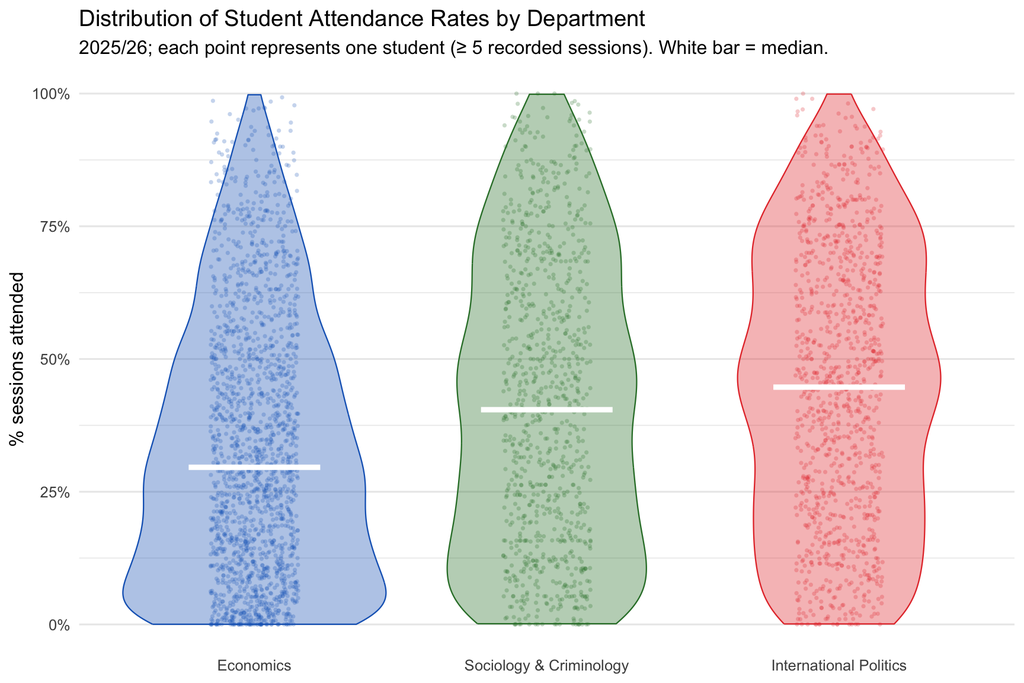

The violin plot reveals how attendance rates are distributed across individual students within each of the three SPGA departments, rather than simply comparing averages. The distributions differ markedly across departments, both in their central tendency and in their shape.

Economics shows the lowest median attendance of the three departments, with the bulk of its distribution concentrated below 50%. The violin is widest in the lower range, indicating that a large share of Economics students attend fewer than half of their scheduled sessions. This pattern is notably different from the other two departments and suggests a structural challenge that goes beyond a small group of chronically absent individuals.

Sociology & Criminology occupies a middle position, with a median of approximately 40–45% and a more evenly spread distribution. While there is substantial variability among students, the distribution does not concentrate as sharply at the low end as Economics, and a meaningful proportion of students achieve higher attendance rates.

International Politics shows the highest median attendance of the three, with a distribution that is wider at the upper end and displays a modest bimodal character — a concentration of students attending consistently at high rates alongside a lower tail of less engaged students. These differences in distributional shape, rather than average levels alone, point to where targeted support may be most needed, with Economics standing out as the department where low attendance is most prevalent and most systematic.

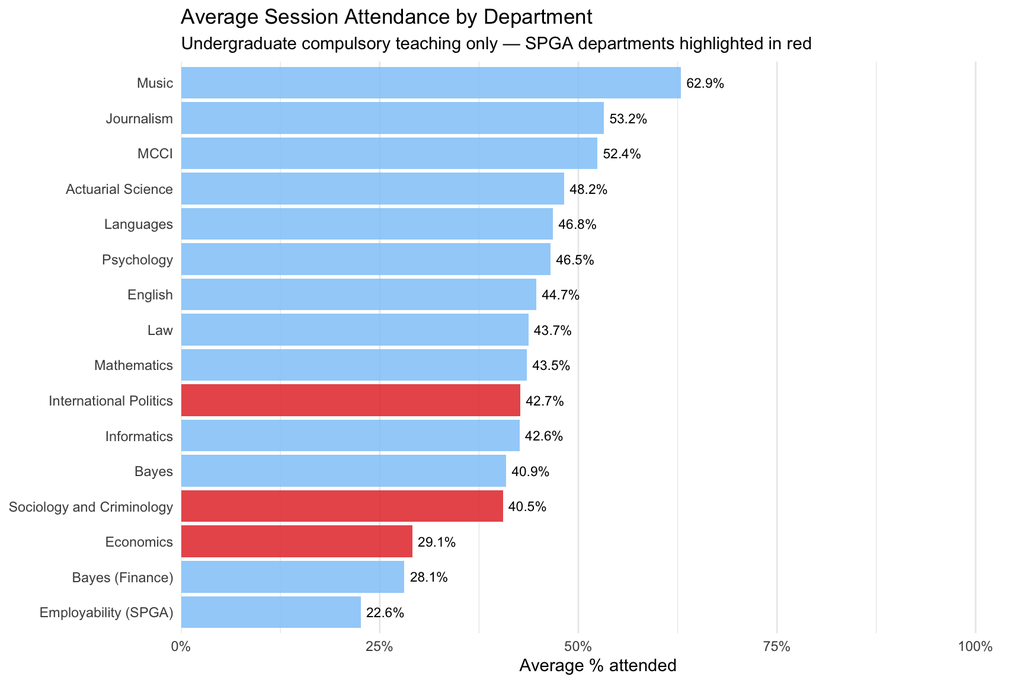

The three SPGA departments occupy different positions in the university-wide ranking, and the differences between them are substantial. International Politics, at 42.7%, sits broadly in the middle of the distribution, comparable to Mathematics (43.5%) and Informatics (42.6%). Sociology & Criminology, at 40.5%, is somewhat below the midpoint, broadly in line with the Bayes Business School average. Economics, at 29.1%, is near the bottom of the distribution — above only Bayes Finance (28.1%) and the Employability module (22.6%), both of which have very different teaching structures. This places Economics as a clear outlier within the SPGA, with attendance levels markedly lower than its peer departments in the school.

The highest-attending departments — Music, Journalism, and MCCI — deliver a substantial share of their teaching through practical studio, production, and performance-based activities where physical presence is operationally required. When SPGA departments are compared against lecture- and seminar-based disciplines more similar in structure, International Politics and Sociology & Criminology perform comparably; Economics, however, falls significantly below this peer group as well.

## 2.3 Comparison with Previous Academic Years

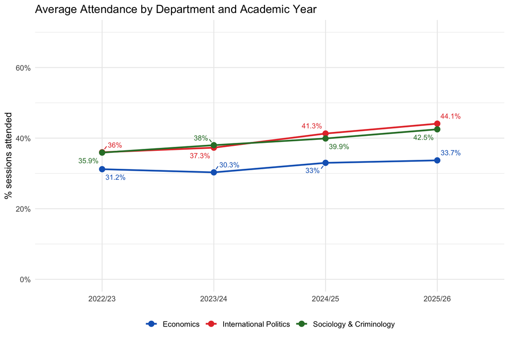

Across the three SPGA departments, attendance in 2025/26 is broadly in line with 2024/25. Note that Economics and Sociology & Criminology may have limited records in earlier academic years depending on when data extraction began, so year-on-year comparisons for those departments should be treated with caution. For International Politics, where data extend back to 2022/23, comparisons with years prior to 2024/25 should also be read carefully given changes to the notification and reminder system for domestic students introduced around that time; earlier years may therefore not be fully comparable.

## 2.4 Attendance and Timetabling

### 2.4.1 Within and Across Terms

The chart below show two consistent patterns. First, attendance declines progressively within each term: the later the week, the lower the average attendance rate, and this within-term erosion is visible in both Term 1 and Term 2. Second, attendance in Term 2 is substantially and consistently lower than attendance in the equivalent week of Term 1 — the gap opens from the very first week of the second term and is maintained throughout. These two patterns — within-term decline and a Term 2 level shift — are both confirmed by the multivariate model, which shows that they persist after controlling for timetabling, student characteristics, and module-level factors.

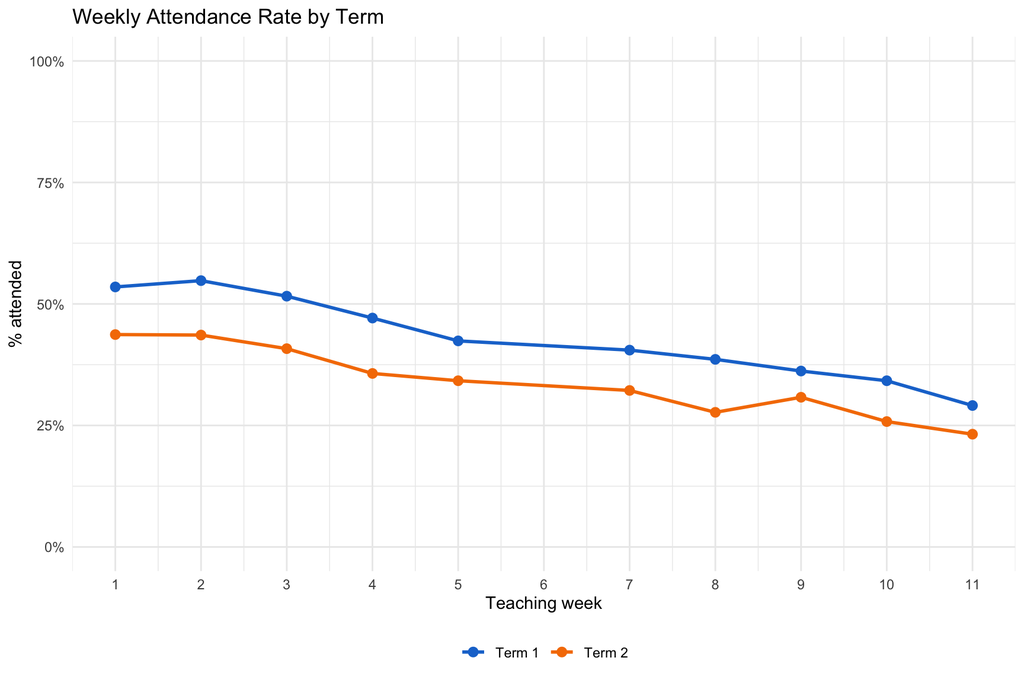

### 2.4.2 Day of Week

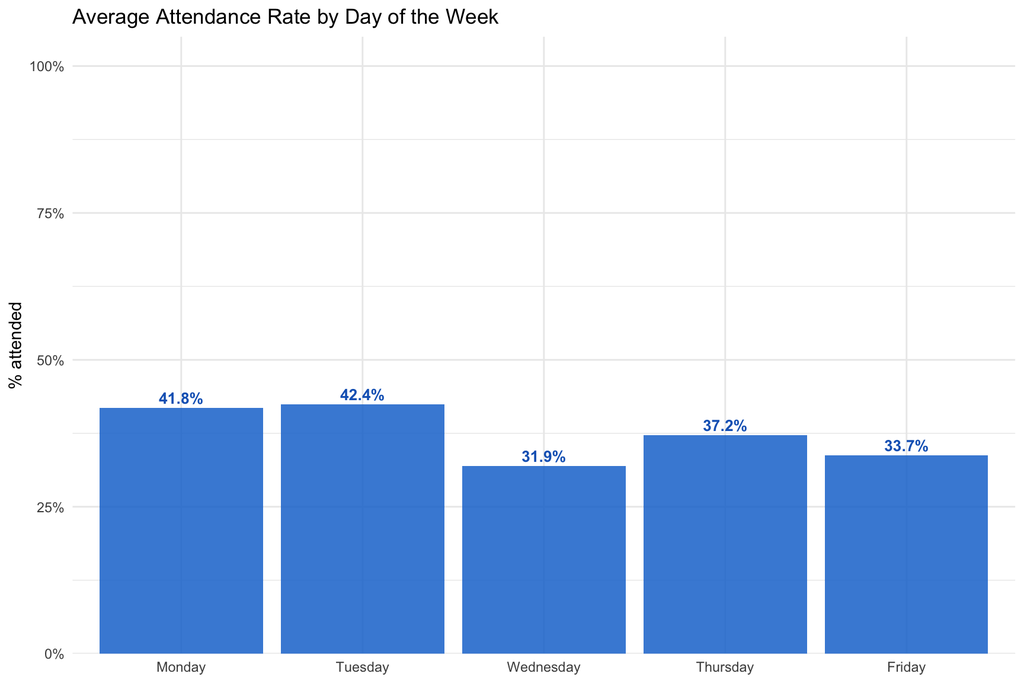

### 2.4.3 Time of the Day

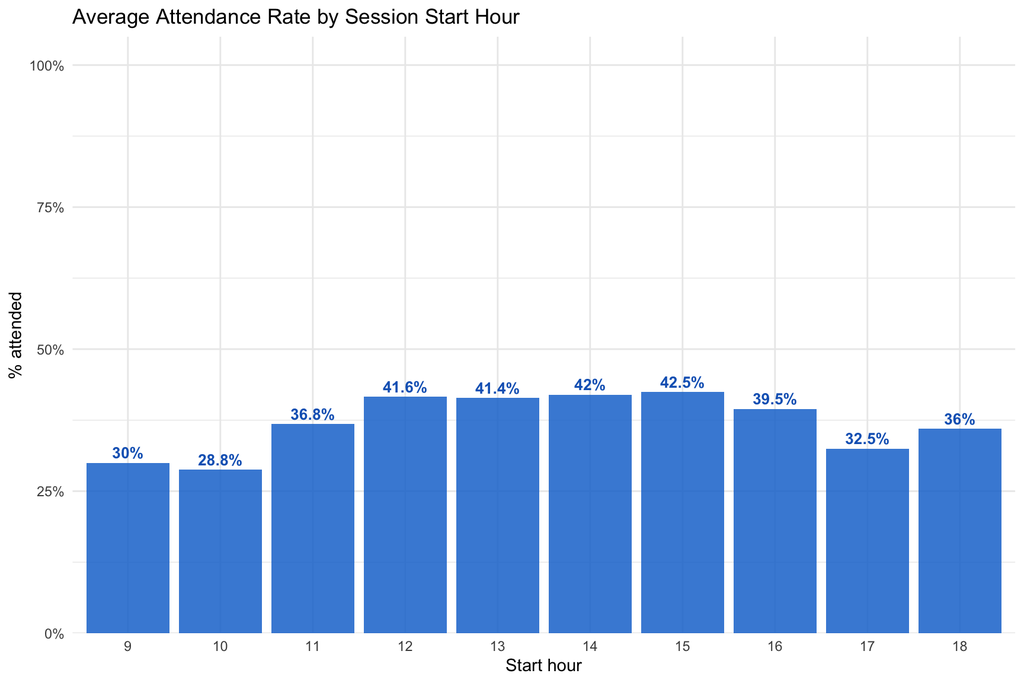

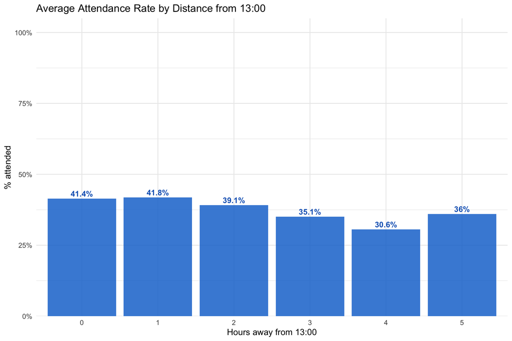

### 2.4.4 Number of Modules in the Day

The chart below shows average attendance by the number of other modules of the **same delivery mode** a student has scheduled on the same day. Students with a single on-campus (or online) module on a given day attend just 35.9% of their classes on that day on average — the lowest of any group. Attendance rises as the number of same-mode sessions increases: students with two same-mode sessions average 39.4%, and those with three record 43%. Students with four same-mode sessions average 41.3%, suggesting that the benefit levels off or dips slightly on the busiest days. Separating by delivery mode refines the earlier finding: the “sunk cost of commuting” logic applies specifically within a mode — the commitment of travelling to campus (or logging into an online session) appears to lower the marginal cost of attending subsequent sessions of the same type. This positive association is confirmed by the multivariate model.

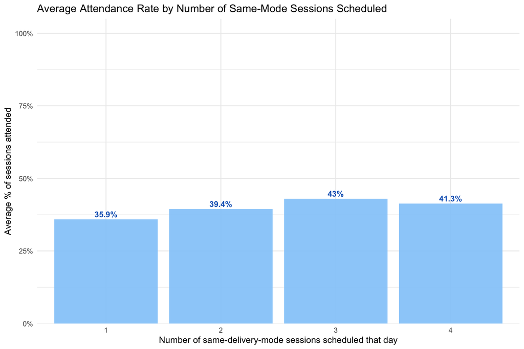

## 2.5 Attendance by Cohort

The chart below shows raw attendance rates by year of study. In the descriptive data, second- and third-year students attend at lower rates than first-year students on average. However, this raw difference should be interpreted cautiously: older cohorts tend to have less favourable timetabling conditions — more Friday sessions, earlier start times, and more dispersed schedules — which independently reduce attendance. The multivariate model accounts for these differences and finds that a substantial cohort effect persists even after holding timetabling factors constant, confirming that year of study has an independent negative association with attendance beyond what can be explained by scheduling alone.

One data coverage caveat applies specifically to the PGT cohort. PGT modules moved to recording attendance via card reader only in Term 2; Term 1 PGT attendance was not captured through the same system as undergraduate sessions. The PGT figures in this section therefore reflect Term 2 data only and may not be directly comparable to the undergraduate cohorts, which are drawn from both terms.

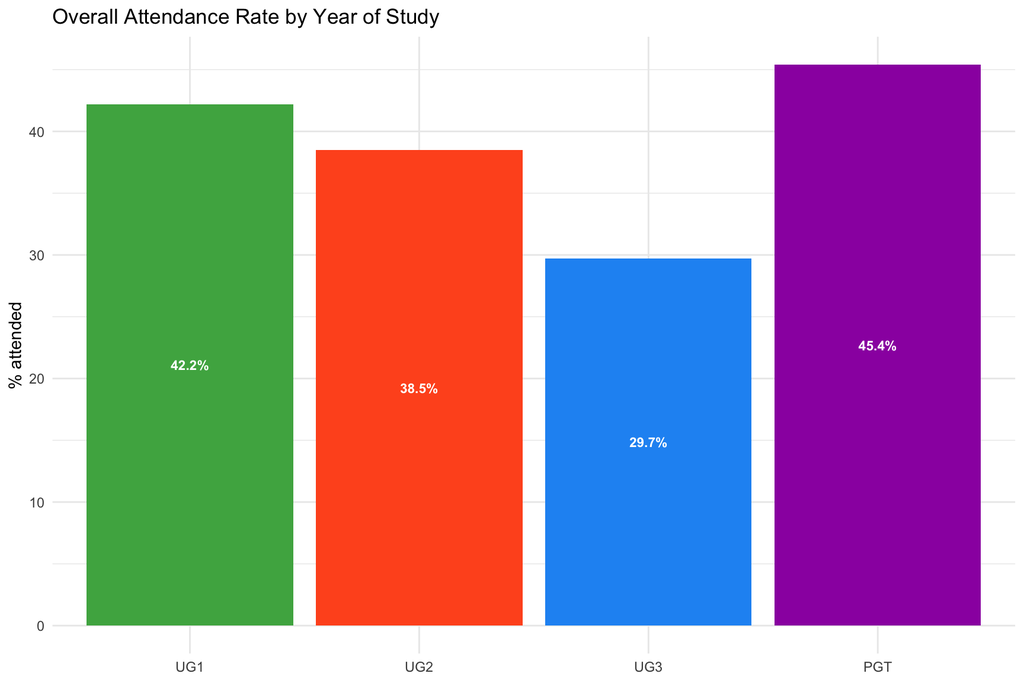

## 2.6 Attendance by Delivery Mode

### 2.6.1 Class Type

Attendance varies across class formats, and the mix of formats differs across departments. The predominant model in Economics and Sociology & Criminology is a one-hour **lecture** accompanied by separately scheduled **tutorials** or **computer labs** in which smaller groups of students work through problems, discuss material, or complete structured exercises. In the International Politics department, this two-session model is often replaced by a single two-hour **workshop** that combines the lecture and tutorial elements into one extended session — reducing scheduling complexity but making it harder to separate the contribution of each component to student engagement.

Two important caveats apply: (1) for two-hour **workshops**, the swipe-card system captures the start of the session but cannot detect students who leave during the mid-session break and do not return — recorded attendance for workshops is therefore likely to be slightly inflated relative to true sustained engagement; (2) for **tutorials and seminars**, students registered for one group who attend a different group’s session are recorded as absent in their own group’s record — tutorial attendance figures therefore undercount actual presence to an unknown degree.

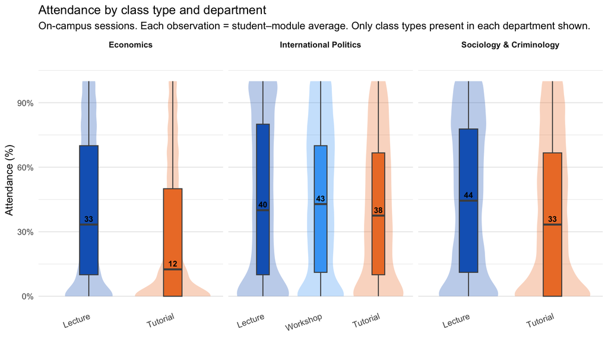

### 2.6.2 Class Size

The scatterplot below shows session-level attendance against class size. Contrary to what a simple crowding hypothesis would predict, the LOESS curve shows a slightly positive relationship: after a brief dip around classes of 50 students, attendance rates rise modestly and consistently as class size increases, reaching roughly 45–50% for the largest sessions. There is, however, very substantial variability at all class sizes — particularly for small seminars, where attendance ranges from near zero to 100%. This positive association is confirmed by the multivariate model (OR ~1.20 per SD increase in class size).

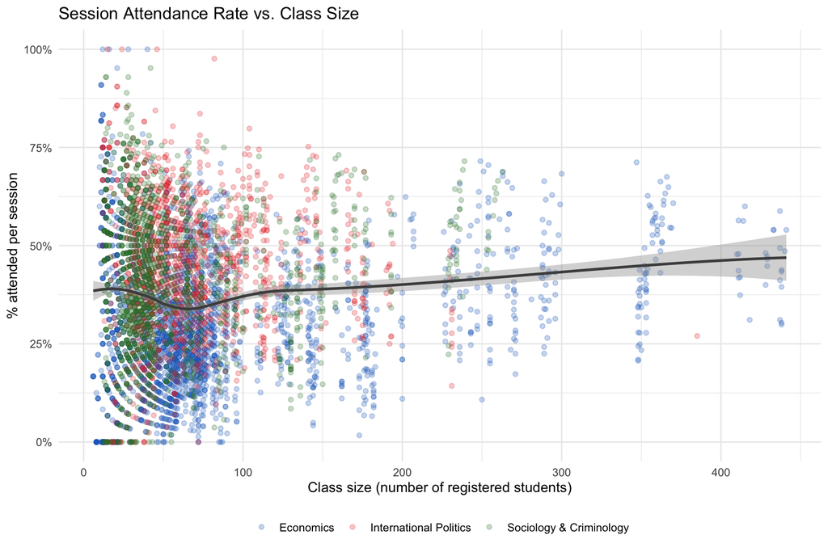

### 2.6.3 Online vs On Campus

SPGA participated in the eAttend pilot alongside SHMS and CLS in 2025/26, enabling automated capture of online attendance within the existing SEAtS system. This extended session-level monitoring to online classes without requiring students to check in manually. However, technical issues affected the reliability of online attendance capture during the pilot phase, particularly in Term 1, creating data quality concerns for the online attendance figures. The findings on online attendance reported in this section should therefore be interpreted with that caveat in mind, especially for Term 1 comparisons.

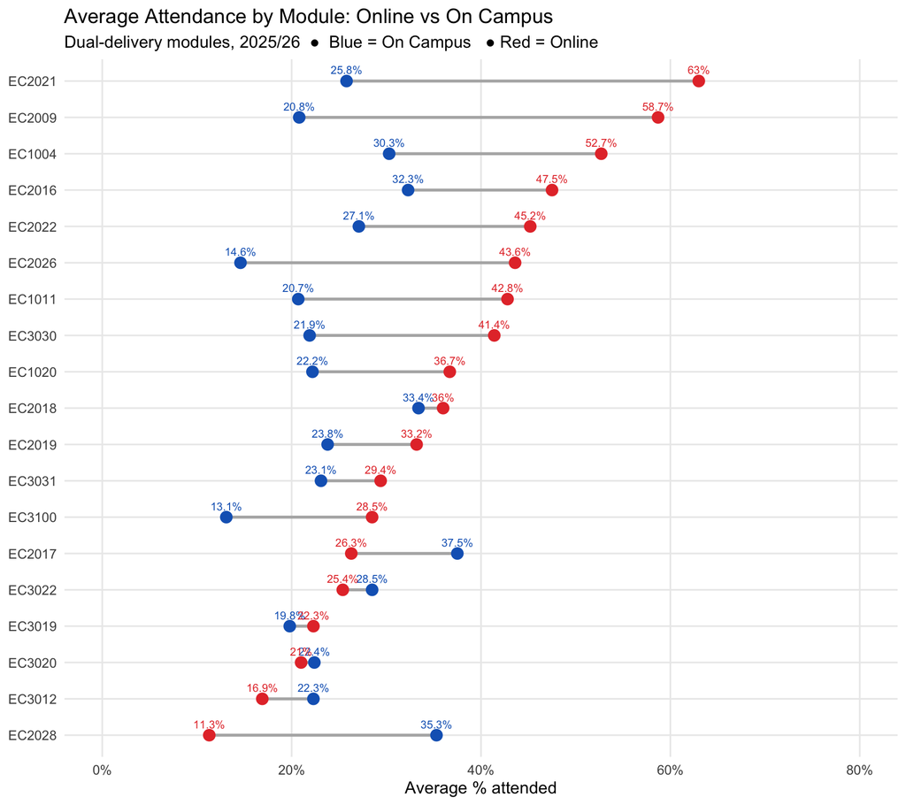

The chart restricts the comparison to **modules that run sessions in both delivery modes in 2025/26**, and within those modules excludes in-person lectures — which have no online counterpart. Online sessions are identified by the presence of a virtual room or an “Online” session-type label; in-person sessions are all remaining non-lecture slots (tutorials, labs, seminars) in the same modules. In 2025/26, the sessions meeting this criterion are predominantly Economics tutorials and lab sessions.

The median attendance for on-campus sessions in this matched sample is 24.4%, compared to 36.7% for their online counterparts. This within-module, within-session-type comparison anticipates what the multivariate model reports for online delivery. After controlling for session type (`LessonType` fixed effect), department, timetabling factors, and student characteristics — and with session-level random effects absorbing unobserved within-module variation — online sessions see relatively higher attendance than equivalent in-person ones, likely because logging in from home carries a lower barrier than travelling to campus.

### 2.6.4 Lecture Capture

A module is coded as having **lecture recording** if more than half of its lectures are captured via Panopto/Echo360 and made available on Moodle, or if the module convenor has uploaded pre-recorded lectures as a flipped-classroom model. A second coding distinguishes whether recordings are also available for tutorials, labs, and seminars. The data come from the SPGA Moodle Audit and cover lectures/workshops and tutorials/labs separately.

The question of interest is whether the availability of a recording is associated with *lower* attendance — a substitution effect where students skip sessions knowing they can watch later — or whether it is neutral or even complementary. The descriptive analysis below is restricted to on-campus sessions.

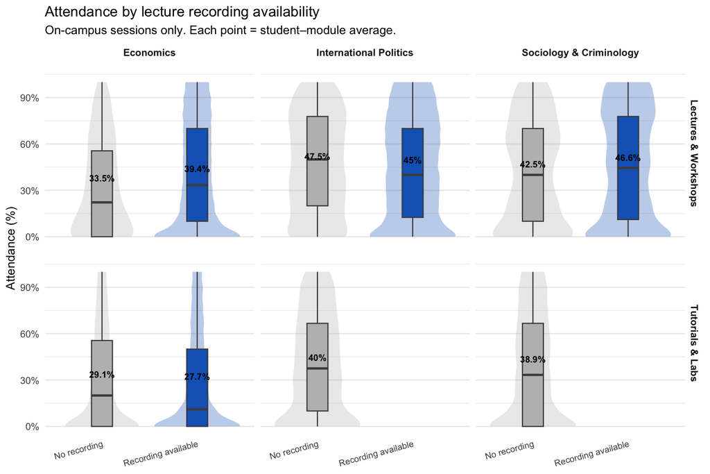

## 2.7 Attendance and Individual Student Characteristics

### 2.7.1 Prior-Year Attendance

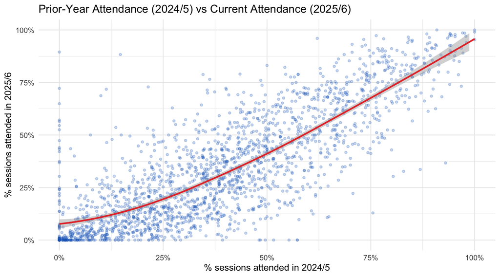

Prior-year attendance is one of the strongest student-level predictors of current-year attendance. Students who attended reliably in 2024/5 tend to do so again in 2025/6, and those who missed frequently last year continue to miss at higher rates this year. The positive association is visible across the full range of attendance values, though with considerable spread around the LOESS curve, indicating that prior attendance is a useful but far from deterministic signal. This persistence in attendance behaviour supports its inclusion in the statistical model as a control, where it is among the largest fixed-effect estimates.

### 2.7.2 Distance from Campus

Distance is measured as the straight-line distance in kilometres between the campus postcode (EC1V 0HB) and the postcode of each student’s registered home address, geocoded via the postcodes.io API. This is an approximation of commuting distance and does not reflect the student’s actual mode of travel or the route taken.

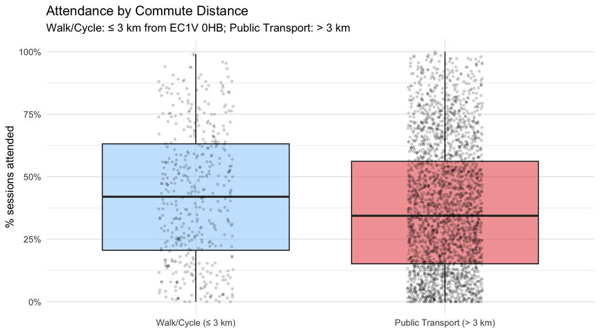

Splitting students at the 3 km threshold — roughly the boundary between those who can walk or cycle to campus and those who depend on paid public transport — reveals a modest gap in median attendance: 42% for students within walking or cycling distance versus 34.4% for those relying on public transport.

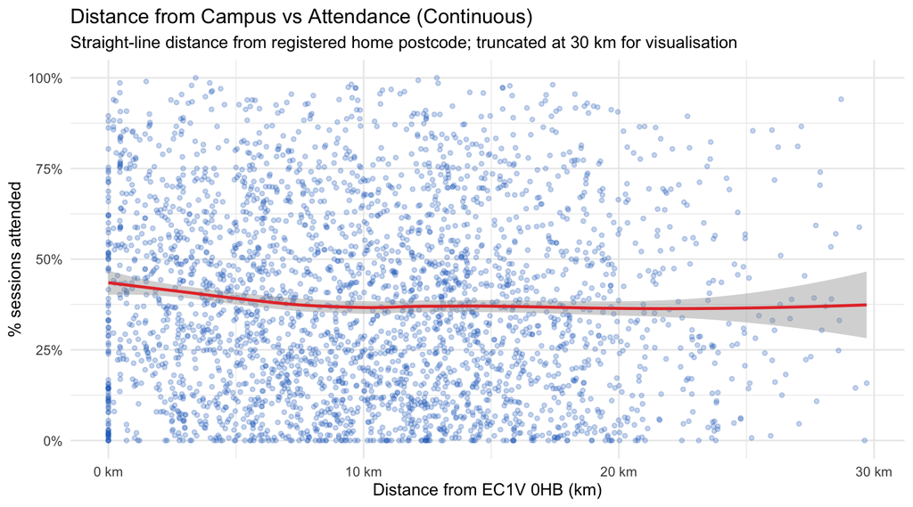

The continuous measure confirms a similar picture, but the negative relation between distance and attendance is only shallow, with no clear threshold beyond which attendance drops sharply.

### 2.7.3 Past Academic Performance

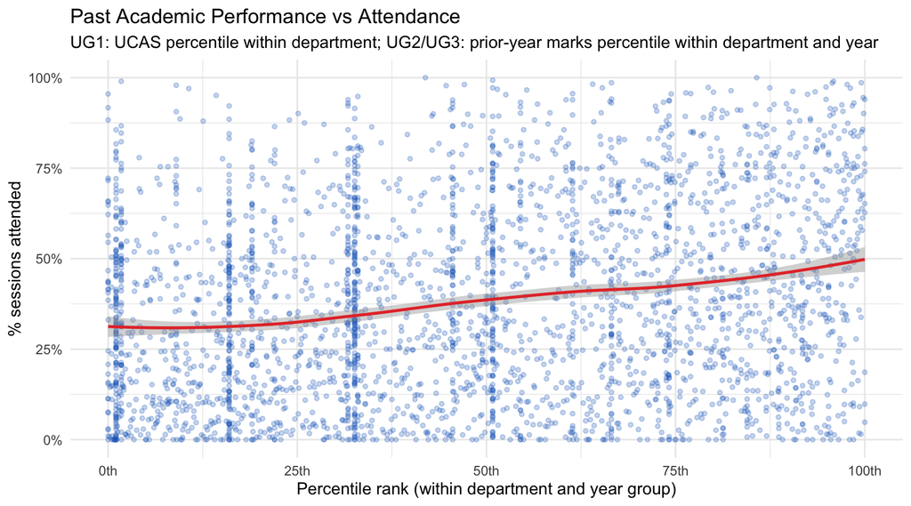

Students who performed better academically relative to their peers tend to have higher attendance. For first-year students, where no university marks are yet available, the measure draws on UCAS entry points ranked within their department; for second- and third-year students, it uses their 2024/5 average mark ranked within their department and year. The LOESS curve shows a gradual positive slope. This relationship holds alongside prior attendance in the statistical model below.

### 2.7.4 Visa Status

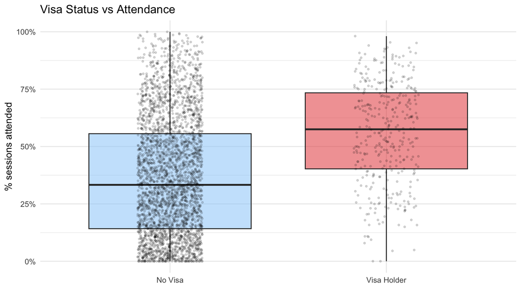

Visa status shows one of the clearest and most consistent attendance gaps in the data. Students on a UK Student visa attend at substantially higher rates than their non-visa peers, with a separation visible in both the medians and the shape of the distributions: the visa-holder distribution is more tightly clustered at the upper end, while the non-visa distribution has a much longer lower tail. This pattern directly reflects the compliance incentive built into the UK Student visa regime, under which universities are required to monitor and report attendance, and students risk losing their visa status if they fall below the required threshold. The model estimates this as one of the largest individual-level effects in the data.

### 2.7.5 Admission Mode (Clearing vs Direct Entry)

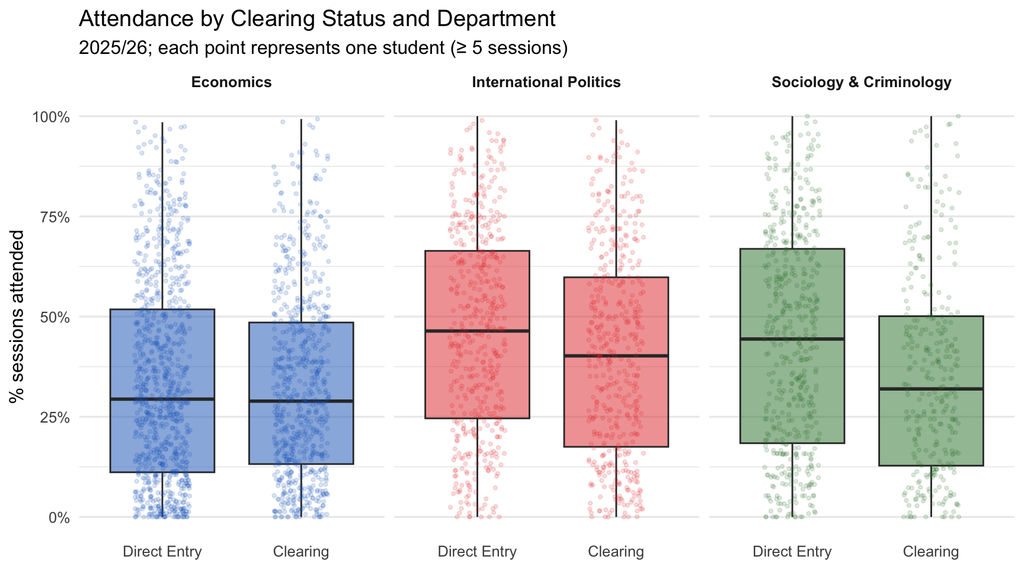

The chart disaggregates the clearing entry effect by department, revealing a pattern that differs markedly from what the overall model estimate might suggest. In **Economics**, the two groups are virtually indistinguishable — Clearing and direct-entry students share almost the same median attendance, and the distributions overlap almost entirely, so the attendance penalty associated with Clearing entry is effectively absent. By contrast, the gap is visible in **International Politics** and most pronounced in **Sociology & Criminology**, where Clearing students have a noticeably lower median and a wider lower tail. The overall model estimate (OR ~0.93) is therefore driven primarily by International Politics and Sociology & Criminology rather than Economics, where Clearing entry appears to carry no additional attendance disadvantage.

### 2.7.6 Attendance and Gender

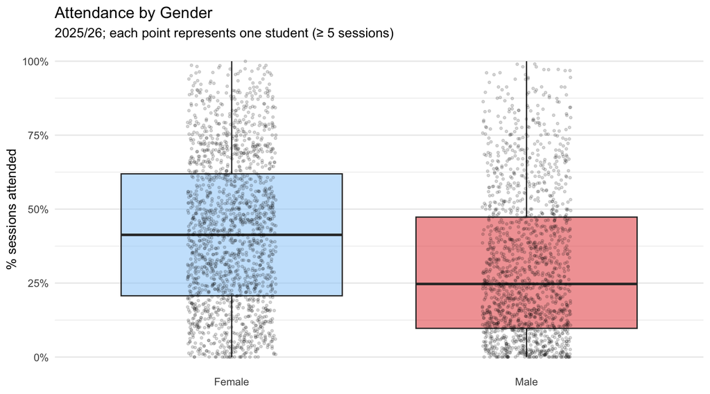

There is a notable gender gap in attendance: female students have a median attendance of 41.3% compared to 24.7% for male students — a difference of 16.6 percentage points. The distributions also differ in shape: the interquartile range for female students (20.7–62%) sits substantially higher than for male students (9.7–47%), and the jitter shows that the greater density of male students at very low attendance rates drives the gap. Both groups show wide within-gender variation, but the difference in central tendency is too large to dismiss as noise. The multivariate models confirm that the gender gap persists after controlling for department, year of study, visa status, and all other predictors: returning students (UG2/3): OR = 1.29 (29% higher odds, p < 0.001); all students: OR = 2 (100% higher odds, p < 0.001). The raw attendance gap visible in the chart is therefore not explained away by differences in cohort composition — gender is an independent predictor of attendance in both cohorts.

### 2.7.7 Attendance and Disability

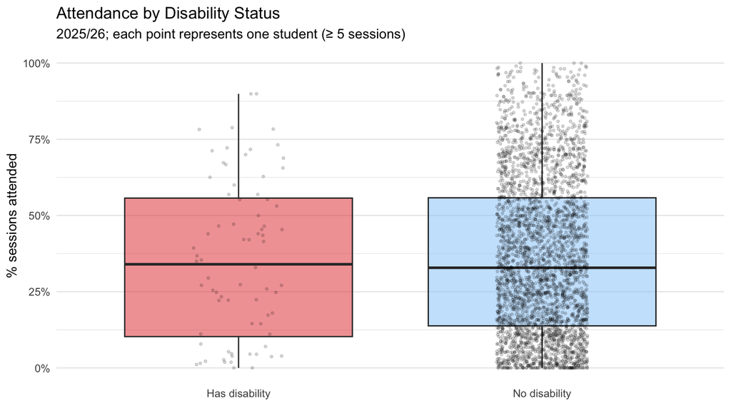

### 2.7.8 Attendance and Socio-Economic Status (Postcode)

The socioeconomic measure used here is the **Index of Multiple Deprivation (IMD) 2019**, an official area-level deprivation index published by the Ministry of Housing, Communities and Local Government. IMD scores all 32,844 Lower Super Output Areas (LSOAs) in England on a composite measure combining income, employment, education, health, crime, and housing deprivation. Each LSOA is assigned a rank (1 = most deprived, 32,844 = least deprived), which is converted to a decile here (decile 1 = most deprived 10%, decile 10 = least deprived 10%).

Student home postcodes were extracted from university records and linked to LSOA codes via the ONS Postcode Directory (ONSPD, May 2025 release). The IMD decile assigned to each student reflects the deprivation level of their home area, not their individual income or wealth. Students with non-UK home addresses, international postcodes, or missing postcode data do not have an IMD score and are excluded from the analysis in this section.

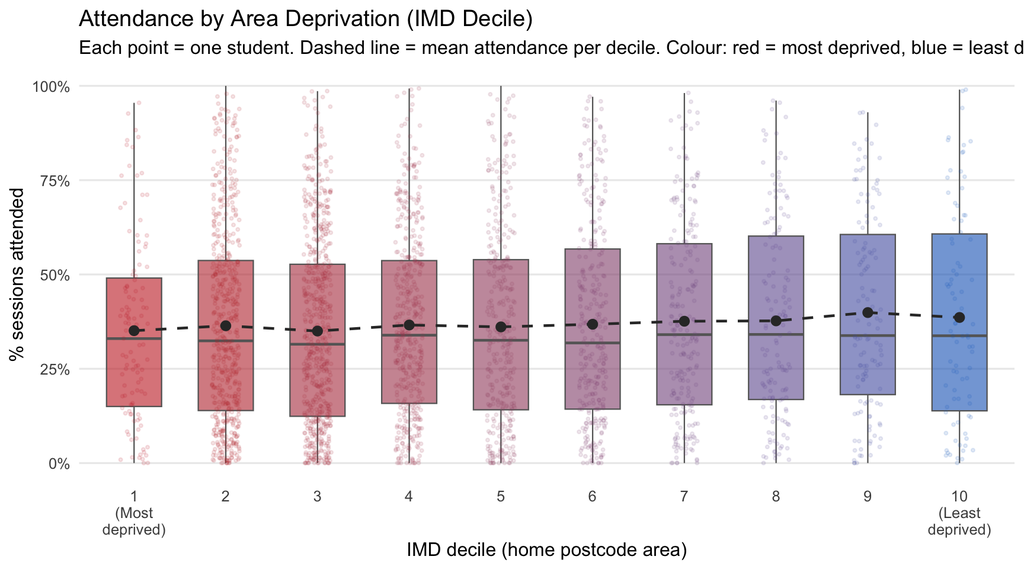

#### 2.7.8.2 POLAR4 Widening Participation Classification

A complementary area-level measure is **POLAR4** (Participation of Local Areas, version 4), published by the Office for Students in 2020. Rather than measuring deprivation directly, POLAR4 measures the rate at which young people from each area progress to higher education. Each Middle-Layer Super Output Area (MSOA) is assigned to one of five quintiles based on the proportion of 18–19 year-olds who started an HE course between 2009–10 and 2013–14: **quintile 1** identifies areas with the lowest HE participation rates (most underrepresented), and **quintile 5** the highest. POLAR4 is the standard widening participation metric used across UK higher education, including in OfS access and participation plans.

Student postcodes were mapped to MSOA codes via the ONSPD (May 2025), then joined to the POLAR4 MSOA-level lookup.

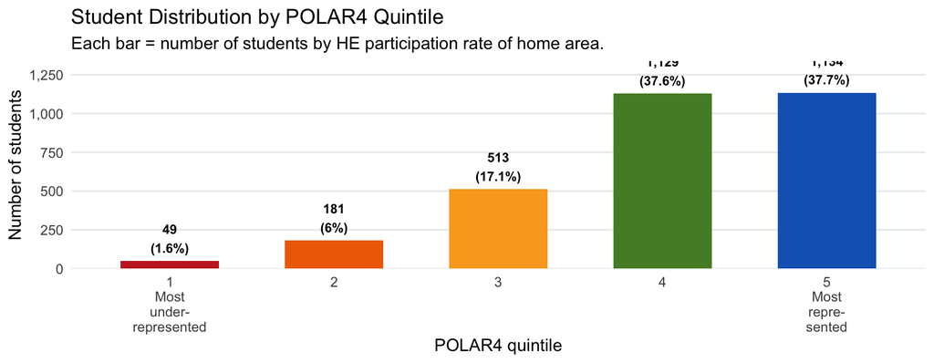

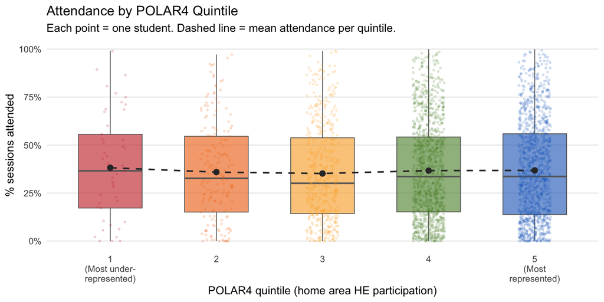

POLAR4 data is available for 3,006 of 3,593 students (83.7%). The distribution is strongly skewed towards higher quintiles: 75.3% of students come from quintile 4 or 5 areas — the most educationally advantaged backgrounds — while only 49 students (1.6%) are from quintile 1 areas Note that quintile 1 contains only 49 students, so its statistics should be interpreted with caution. Median attendance is 36.6% for quintile 1 students and 33.7% for quintile 5 students — a negligible gap of 2.9 percentage points, with students from more represented areas recording lower attendance. As with IMD, these are unadjusted comeparisons and do not control for other student characteristics.

### 2.7.9 Attendance and Ethnicity

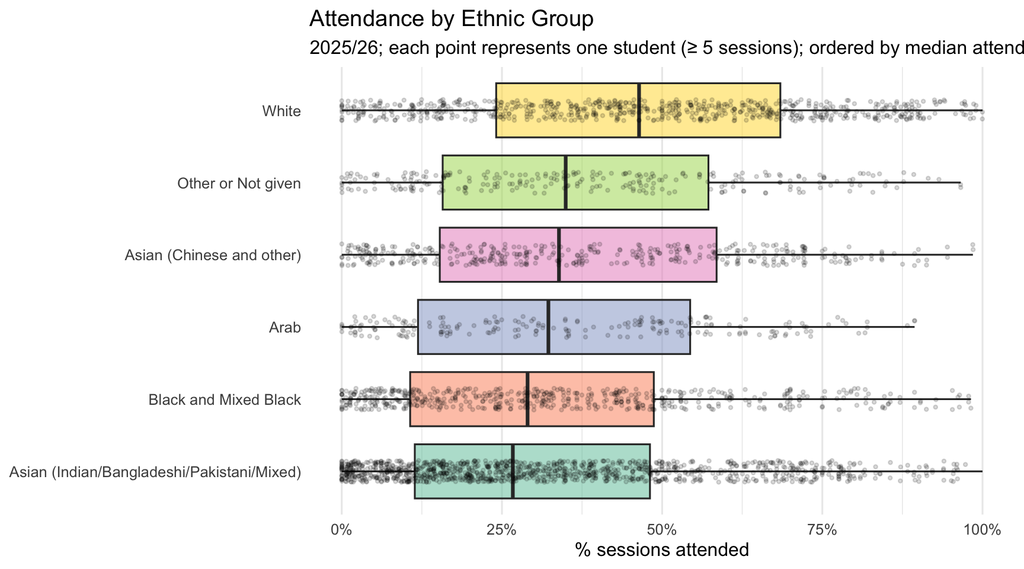

Attendance varies meaningfully across ethnic groups. White students have the highest median attendance (46.4%), sitting clearly above all other groups. The remaining groups fall in a relatively narrow band below: Other or Not given and Asian (Chinese and other) occupy the middle of the distribution, while Black and Mixed Black (29%) and Asian (Indian/Bangladeshi/Pakistani/Mixed) (26.7%) have the lowest medians — a gap of 19.7 percentage points between White students and the lowest-attending group. Arab students (32.2%) sit in the middle of the non-White groups rather than at the lower end. All non-White groups show wide within-group spread, and the larger groups — particularly Asian (Indian/Bangladeshi/Pakistani/Mixed) — have substantial numbers of both high and very low attenders. These are unadjusted comparisons: the groups differ in composition across departments, year of study, and visa status, all of which independently predict attendance. The multivariate models find the following adjusted ethnic attendance gaps relative to White students. In the returning students (UG2/3) model, no ethnic group differs significantly from White students once other factors are controlled. all students: Arab (OR=0.46, lower odds, p<0.001); Asian (Indian/Bangladeshi/Pakistani/Mixed) (OR=0.5, lower odds, p<0.001); Asian (Chinese and other) (OR=0.7, lower odds, p<0.01); Black and Mixed Black (OR=0.52, lower odds, p<0.001); Other or Not given (OR=0.64, lower odds, p<0.01)

## 2.8 Statistical Analysis

### 2.8.1 Model Specification

To identify the independent drivers of attendance, the analysis estimates two complementary mixed-effects logistic regression models. The first uses all students and establishes baseline estimates of structural, timetabling, and demographic effects across the whole school. The second is restricted to returning students (UG2 and UG3) and augments the same specification with two predictors available only for this cohort: prior-year attendance at City (the percentage of sessions attended in 2024/25) and past academic performance measured as the student’s percentile rank on their 2024/25 average mark within department and year group. Both are only meaningful for students who were enrolled in the previous year; for new students they are structurally unobservable. Comparing the two models for the UG2/UG3 subgroup reveals how much of the cohort and structural effects visible in the all-students model are explained by individual academic and attendance history once that information becomes available.

Both models share the same cross-classified random effects structure: a random intercept for each student and a random intercept for each individual weekly occurrence of a teaching session.

The student random intercept allows baseline attendance propensity to vary across individuals, capturing persistent differences in how reliably individual students attend regardless of which session is scheduled. The session random intercept absorbs the shared, unobserved characteristics of the individual session that affects all students in the same specific class meeting on a given day — the tube strike, the proximity of a deadline, an unusually engaging or disorganised session.

Predictors common to both models include day of week, time of day, term, week of term, class size, number of same-mode sessions on the day, department, delivery mode (online vs on campus), session type (lecture, seminar, tutorial, or other — with lecture as reference), visa status, Clearing entry, distance from campus, gender, disability status, and ethnicity.

**Model 1 — All students** includes all four cohorts (UG1, UG2, UG3, PGT) and all structural, timetabling, and demographic predictors. It does not include prior-year attendance, which is only available for returning students. This model provides estimates of structural effects (timetabling, department, demographics) for the full school population, and its Level coefficients capture the net cohort effect including any behavioural persistence not already absorbed by the student random intercept.

**Model 2 — Returning students (UG2 and UG3)** adds two predictors available only for this cohort: prior-year attendance at City (2024/25, as a percentage of sessions attended) and past academic performance measured as the student’s percentile rank on their 2024/25 average mark within department and year group. It also replaces the UCAS-based performance measure used in Model 1 with this university-marks measure, which is a more directly relevant indicator of academic engagement for students who have already completed a year of study. Both variables are available for almost all returning students; any residual missing values are imputed with the within-group mean. This model answers the incremental question: over and above all structural factors, do individual academic and attendance history independently predict current-year attendance? Comparing estimates between Model 1 and Model 2 for the subsample of returning UG2/UG3 students shows how much of the apparent cohort and structural effects in Model 1 are explained by these individual history variables once that information becomes available.

Effect sizes are reported as odds ratios (OR): values above 1 indicate higher odds of attending, values below 1 lower odds. An important clarification on language: an OR does not express a percentage-point change in the attendance rate. It expresses a *relative* change in the odds of attending compared to the reference group or baseline. For example, an OR of 0.84 means the odds of attending are 16% lower — but if the baseline attendance rate is around 70%, this translates to roughly a 3–4 percentage point reduction in the actual probability of attending, not 16 points. Where the text below says a factor “increases/reduces the odds by X%”, this always refers to this relative change in odds. Because the large sample size naturally produces statistically significant p-values across the board, confidence intervals and the magnitude of the odds ratios are used to assess the practical importance of each finding.

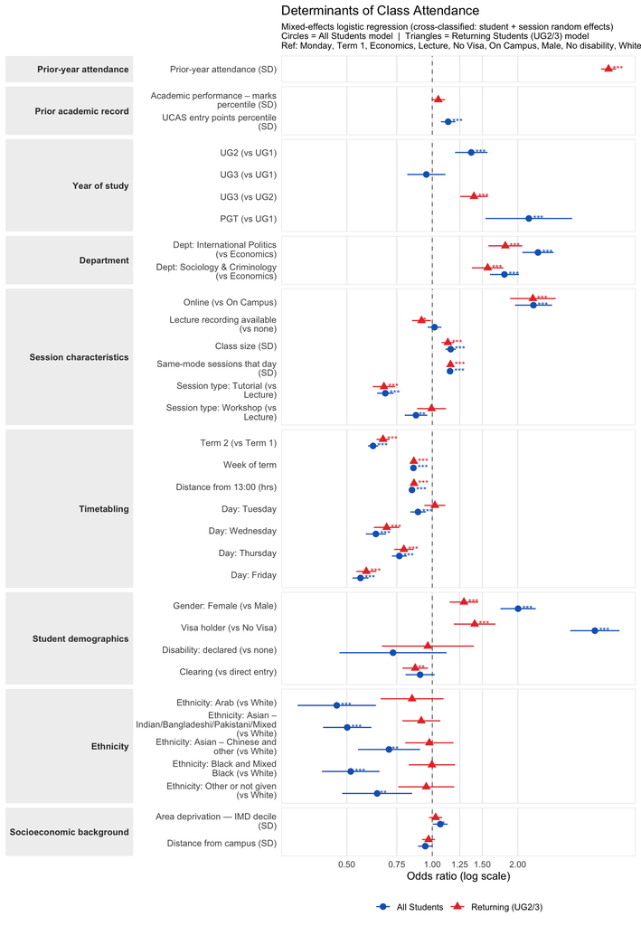

### 2.8.2 Summary of Findings

[output not shown]

**Interpreting the two models side by side.** A key pattern is that attendance gaps associated with ethnicity and declared disability are larger in the All Students model but attenuate — sometimes considerably — in the Returning Students model once prior-year attendance is added. This is not a modelling artefact: prior-year attendance is itself the product of the same structural barriers (transport costs, health needs, caring responsibilities) that disproportionately affect minority ethnic students and students with disabilities. When prior attendance is added to the model it absorbs a share of the current-year gap, because students who faced these barriers last year are more likely to face them again. The two models therefore answer different questions: the All Students model reports the *total observed* attendance gap; the Returning Students model reports the *residual* gap that persists even after established habits are accounted for. The difference between the two estimates represents the share of the gap mediated through habitual attendance patterns — itself an important finding about how disadvantage compounds across cohorts.

# 3 Online Engagement in SPGA

## 3.1 Data on Online Engagement

The data for this report are drawn from the Moodle activity logs capturing student engagement across all undergraduate and postgraduate modules offered by the three SPGA departments — Economics (EC), International Politics (IP), and Sociology & Criminology (SG) — during the 2025/26 academic year. The logs record each instance of a student viewing or interacting with a Moodle resource, along with a timestamp, the student’s name, the module, and the type of component accessed. Data was extracted on 29 April 2026 and therefore covers the full teaching period for both Term 1 and Term 2 as well as the revision and assessment period that followed (partially truncated for Term 2 given the extraction date). Prior to analysis, the logs were cleaned to remove entries generated by teaching staff and course administrators.

The analysis focuses on student interactions with discrete learning resources — specifically files, URLs, forum posts, external tools, and SCORM packages — and excludes course-level navigation events and assignment submission pages. Each resource was assigned to one of the following categories based on its name and component type:

- **Lecture Slides**: Files whose names include terms such as “slides”, “lecture notes”, or “PowerPoint”.
- **Lecture Capture and Pre-Recorded Video**: Links, external tools, and SCORM packages providing access to recorded or pre-recorded instructional video content, identified by terms such as “recording”, “Panopto”, “Echo”, “Replay”, “video”, or by use of the SCORM package component type.
- **Assessment Guidance**: Resources related to assignments, coursework, or academic writing, identified by terms such as “assignment”, “marking criteria”, “essay guidance”, “submission”, or “rubric”.
- **Linked Learning Resources**: External readings and linked materials, identified by terms such as “reading list”, “readings”, author–date citations, journal or chapter references, policy briefs, and similar patterns.
- **Learning Activities**: In-class and preparatory tasks, identified by terms such as “worksheet”, “seminar brief”, “seminar guide”, “exercise”, or “problem set”.

Resources that did not match any of these patterns were flagged as “Unclassified”, with a subset reclassified by inspection of the resource title.

Moodle resources by department: number of modules, total student clicks, and number of distinct resources by category.

| Department | Modules | Total Clicks | Number of distinct resources by category Lecture Slides | Number of distinct resources by category Lecture Capture and Pre-Recorded Video | Number of distinct resources by category Assessment Guidance | Number of distinct resources by category Linked Learning Resources | Number of distinct resources by category Learning Activities | Number of distinct resources by category Unclassified |
| --- | --- | --- | --- | --- | --- | --- | --- | --- |
| Economics | 45 | 604,819 | 313 | 454 | 288 | 252 | 552 | 874 |
| International Politics | 59 | 184,918 | 484 | 356 | 184 | 505 | 80 | 859 |
| Sociology & Criminology | 44 | 125,359 | 432 | 176 | 171 | 317 | 67 | 717 |

Two important caveats apply to how engagement with these resources should be interpreted. First, the Moodle logs record only the act of clicking on a link to open a resource — they do not capture what the student did afterwards. There is no way from this data to determine whether a student read an article in full, watched a video to completion, or simply opened and immediately closed a file. A single click is recorded identically regardless of the depth of engagement that followed. Second, the coverage of learning resources in this dataset is necessarily limited to materials that are directly linked within the Moodle page. In cases where a module convenor listed required readings in text without creating individual hyperlinks — expecting students to locate the materials independently through the university library — those readings are invisible to this analysis. Similarly, where a module provides a single link to an electronic reading list (for example via the university’s reading list system), only that one click is recorded: the data does not capture whether the student then opened any of the individual readings within the list. The engagement figures reported below should therefore be understood as a measure of how students interact with the Moodle page itself, rather than a complete picture of their broader study activity.

## 3.2 Online Resource Availability and Access

Before examining how students engage with Moodle resources, it is important to recognise that the supply of materials itself varies considerably across modules. Not all modules provide the same volume or mix of online resources: some post a small number of core materials while others upload a large and varied catalogue spanning lecture slides, readings, assessment guidance, and instructional videos. This variation is not simply a reflection of departmental policy — it is apparent within each department, meaning that students enrolled in different modules in the same department can face strikingly different online learning environments. The charts below illustrate this heterogeneity in resource availability, both in terms of the total number of materials posted and the types of resources that make up each module’s catalogue.

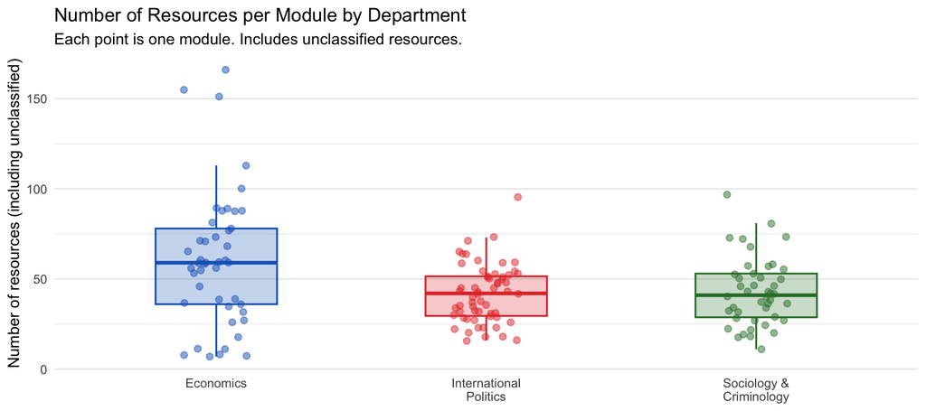

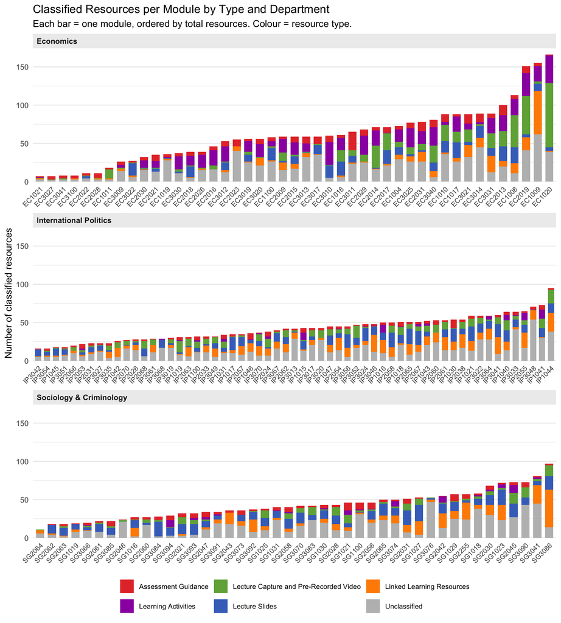

One question is whether modules that post more resources encourage greater online engagement orsee lower coverage —or whether the two are unrelated.

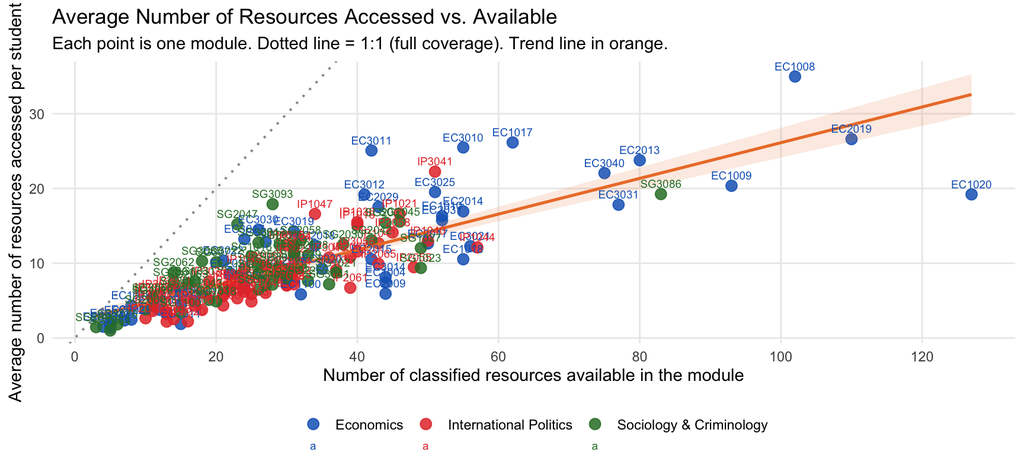

As the number of resources posted in a module increases, students access more resources in absolute terms — but they do not keep pace with the expanding catalogue. The dotted 1:1 reference line represents the hypothetical case in which every student accesses every resource: all modules fall well below this line, confirming that full coverage is never achieved. The positive slope of the trend line shows that modules with more resources do tend to see more total accesses per student, but at a diminishing rate.

In other words, posting more materials yields some additional engagement, but a larger share of those extra resources goes unaccessed.

Turning to the percentage of available resources accessed by students, the chart below shows a negative relationship between catalogue size and average coverage: modules with more resources tend to see a lower fraction of those resources accessed per student. However, the trend line is notably shallow — the slope is modest and the confidence interval wide — indicating that the dilution effect, while present, is relatively weak. Coverage varies enormously across modules at every level of catalogue size, as the wide scatter of points makes clear. The dominant story is not that larger catalogues systematically depress engagement, but that module-level idiosyncrasies — how resources are signposted, whether they are tied to assessments, how the module is taught — account for far more of the variation than catalogue size alone.

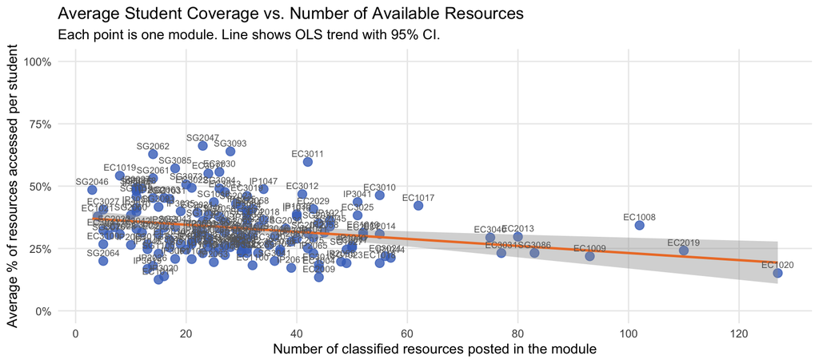

This is consistent with the dilution effect suggested by the percentage-coverage chart: the typical student has a roughly fixed budget of engagement that does not scale proportionally with the size of the catalogue.

## 3.3 How much students access learning resources on Moodle?

### 3.3.1 Access across modules

A first way to characterise the scale of student engagement with Moodle is to look at the raw number of distinct resources each student accesses in a given module — that is, how many individual files, links, or activities they open at least once, irrespective of the size of the module’s total catalogue.

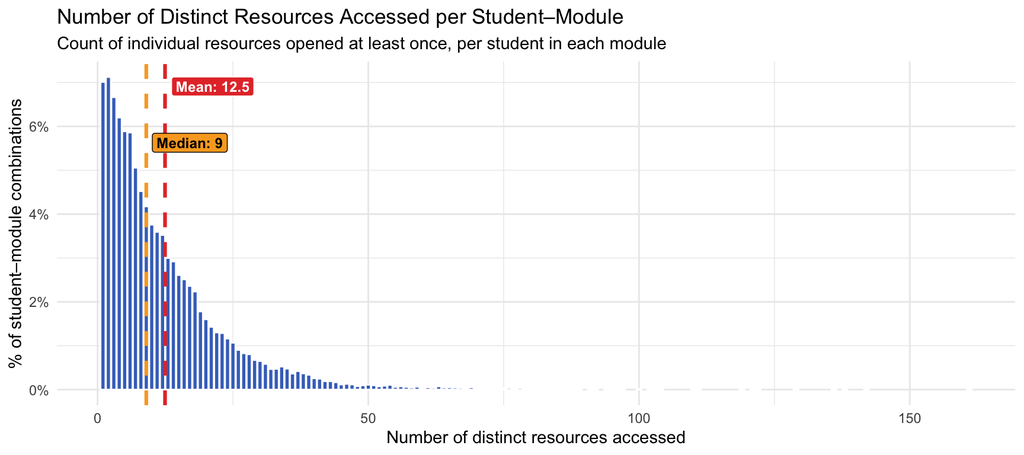

The distribution of distinct resources accessed per student–module combination is strongly right-skewed. The **median is 9 resources**, meaning that half of all student–module combinations involve a student opening fewer than that number of distinct materials over the course of the module. The **mean of 12.5** is pulled upward by a long tail of high-engagement students who access a large number of individual resources. This pattern is consistent with a two-speed engagement dynamic: a majority of students interact with a small core of materials — likely those most directly tied to assessments or explicitly required in class — while a smaller group engages broadly across the full catalogue. The gap between mean and median quantifies this asymmetry and signals that averages alone would overstate the typical student’s level of engagement.

Given the diversity in the availability of resources online, a follow-up question is how significant are these numbers. The histogram below captures this by exploring what fraction of the available materials in a module students actually open. For each student–module combination, the graph below shows the percentage of classified resources posted on that module’s Moodle page that the student accessed at least once, regardless of how many times they clicked or how long they spent on each item.

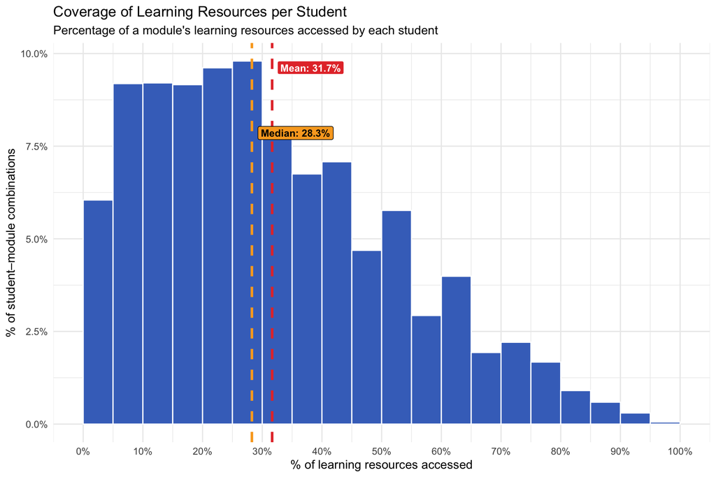